# Nouveautés de PostgreSQL 14

Workshop 14

Dalibo & Contributors

# Nouveautés de PostgreSQL 14

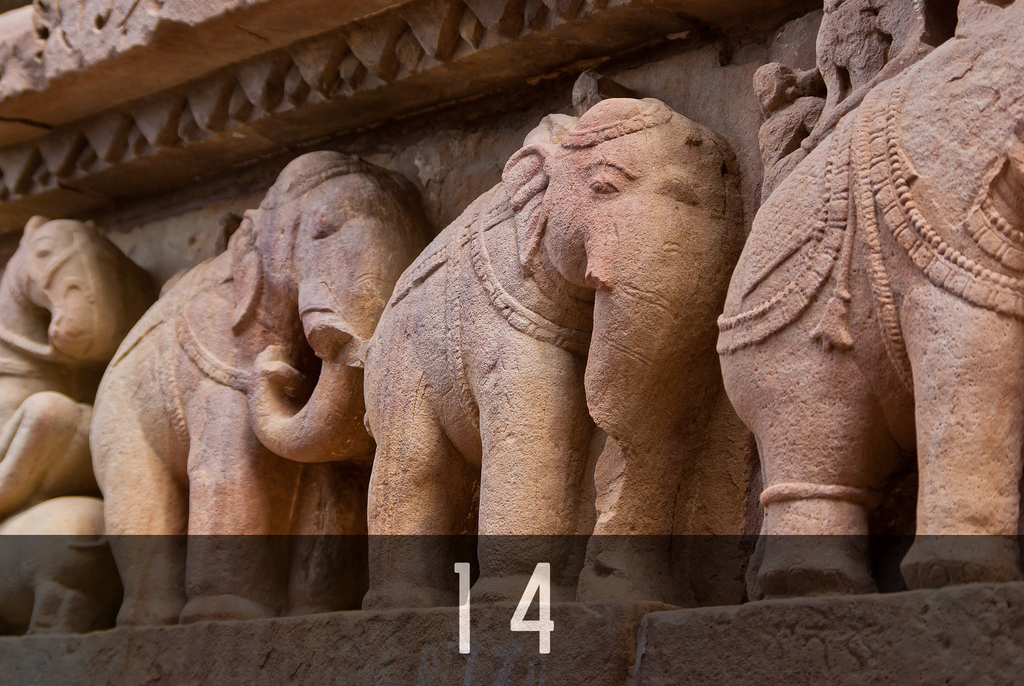

## Les nouveautés

- Administration
- Réplication
- Développement et syntaxe SQL
- Supervision
- Performances

## Administration et maintenance

- Sécurité
- Configuration
- Outils clients
- Partitionnement
- Divers

### Sécurité

#### Authentification SCRAM-SHA-256 par défaut

Défaut à présent : `password_encryption` = `scram-sha-256`

- Utilisation conseillée depuis la version 10 !
- Migration :
  - utilisateur par utilisateur
  - `SET password_encryption TO "scram-sha-256" ;`
  - ré-entrer le mot de passe
  - dans `pg_hba.conf` : `md5` → `scram-sha-256`

#### Nouveaux rôles prédéfinis

- `pg_read_all_data`
- `pg_write_all_data`
- `pg_database_owner` (*template*)

### Nouveautés de configuration (GUC)

#### Nouveaux caractères d’échappement pour log_line_prefix

`log_line_prefix` : enrichit le préfixe des lignes de la sortie d’erreur

- `%P` : identifiant du processus principal (*parallel leader*)
  - si l’entrée de journal provient d’un processus auxiliaire (*parallel worker*)
- `%Q` : identifiant de la requête (nouveauté)
  - si le calcul interne de l’identifiant est actif

#### Temps d’attente maximal pour une session inactive

- Nouveau paramètre `idle_session_timeout`
- Temps d’attente avant d’interrompre une session inactive
  - Désactivé par défaut (valeur `0`)
  - Comportement voisin de `idle_in_transaction_session_timeout`
  - Paramètre de session, ou globalement pour l’instance

#### Modification à chaud de la restore_command

- Le paramètre `restore_command` ne nécessite plus de redémarrage
- Applicable pour les instances secondaires

#### Détection des déconnexions pendant l’exécution d’une requête

- Nouveau paramètre `client_connection_check_interval`
- Détermine le délai entre deux contrôles de connexion
  - Désactivé par défaut (valeur `0`)
  - Utile pour les très longues requêtes
  - Repose sur des appels système non standards (non définis par POSIX)
    - donc Linux uniquement

#### Changements mineurs de configuration

- VACUUM
  - `vacuum_cost_page_miss` = 2 (autrefois : 10)
- Checkpoint :
  - `checkpoint_completion_target` = 0.9 par défaut
- Nouveaux paramètres :
  - `huge_page_size`
  - `log_recovery_conflict_waits`

### Outils clients

#### pg_dump/pg_restore : Possibilité d’exporter et restaurer des partitions individuellement

- `pg_dump` au format *custom*, *directory* ou *tar*
  - L’instruction `CREATE TABLE` ne dépend plus du résultat de la commande `ATTACH`
- `pg_restore` et l’option `--table`
  - Restauration possible d’une partition en tant que simple table
  - Plus simple qu’une restauration avec un *fichier liste* (*table of contents*)

#### pg_dump : Nouvelle option pour exporter les extensions

- `pg_dump --extension=…`
  - spécifier un sous-ensemble d’extensions à exporter
  - exporter les extensions même avec `--schema`

### Partitionnement

#### ALTER TABLE … DETACH PARTITION … CONCURRENTLY

- Détachement de partition non bloquant
- Fonctionne en mode multi-transactions
- Quelques restrictions :
  - Ne fonctionne pas dans un bloc de transactions
  - Impossible en cas de partition par défaut

#### Nouveautés sur REINDEX et reindexdb

- `REINDEX` est maintenant disponible pour les tables et index partitionnés
- Supporte la clause `CONCURRENTLY`
- Fonctionne en mode multi-transactions

### Divers

#### Compression des TOAST configurable en lz4 ou pglz

- Historiquement : `pglz`
- Nouveau : `lz4`, plus rapide
- Définition :
  - `SET default_toast_compression = …`
  - `ALTER TABLE … SET COMPRESSION …`
- Compatibilité : `pg_dump --no-toast-compression`
- N’affecte pas le fonctionnement de la réplication

#### Nouvelle option pour VACUUM : PROCESS_TOAST

- Traite les tables de débordement TOAST lors d’un `VACUUM` manuel
- Activé par défaut

```sql
VACUUM (PROCESS_TOAST false) blog;
```

#### Nouvelle option pour REINDEX : TABLESPACE

- Ajout de l’option `TABLESPACE` pour la commande `REINDEX`
- Possibilité de déplacer des index vers un autre tablespace tout en les reconstruisant
- Avec ou sans la clause `CONCURRENTLY`
- Restrictions :
  - sur les tables et index partitionnés
  - sur les tables TOAST
  - sur le catalogue système

#### Nouvelle fonction pour attendre lorsque l’on arrête un backend

```
pg_terminate_backend ( pid integer, timeout bigint DEFAULT 0 )
```

- Possibilité d’attendre l’arrêt du backend
- Nouveau paramètre `timeout`

## Réplication et Sharding

- Réplication physique
- Réplication logique
- Évolutions pour les *Foreign Data Wrapper*
  - Vers une architecture distribuée (*sharding*)

### Réplication physique

#### Autorise pg_rewind à utiliser un secondaire comme source

- La source d’un *rewind* peut être une instance secondaire

#### Nouveau paramètre de connexion dans libpq

- Nouvelles options pour le paramètre `target_session_attrs`
  - `read-only`, `primary`, `standby`, et `prefer-standby`

### Réplication logique

- Nouveau mode *streaming in-progress* pour la réplication logique
  - à activer
- Informations supplémentaires pour les messages d’erreur de type `columns are missing`
- Ajout de la syntaxe `ALTER SUBSCRIPTION… ADD/DROP PUBLICATION…`

### Foreign Data Wrapper et Sharding

#### Support du TRUNCATE sur les tables distantes

- Nouvelle routine dans l’API Foreign Data Wrapper pour la commande `TRUNCATE`
- Supportée pour les serveurs distants PostgreSQL avec l’extension `postgres_fdw`
- Valable pour les partitions distantes d’une table partitionnée
- Option `truncatable` activée par défaut

#### Lecture asynchrone des tables distantes

- Nouveau nœud d’exécution `Async Foreign Scan`
- `CREATE SERVER … OPTIONS (host …, port …, async_capable on)` (pas par défaut !)
- Lecture parallélisée pour les partitions distantes

```sql
                                    QUERY PLAN
----------------------------------------------------------------------------------
 Append
   ->  Async Foreign Scan on public.async_p1 t1_1
         Output: t1_1.a, t1_1.b, t1_1.c
         Remote SQL: SELECT a, b, c FROM public.base_tbl1 WHERE (((b % 100) = 0))
   ->  Async Foreign Scan on public.async_p2 t1_2
         Output: t1_2.a, t1_2.b, t1_2.c
         Remote SQL: SELECT a, b, c FROM public.base_tbl2 WHERE (((b % 100) = 0))
```

## Développement et syntaxe SQL

### Fonction string_to_table

- Nouvelle fonction pour subdiviser une chaîne de caractère et renvoyer le résultat dans une table :

```sql
SELECT string_to_table('une chaine à ignorer', ' ', 'ignorer');

string_to_table
-----------------
 une
 chaine
 à
 ¤
```

- Alternative plus performante à `regexp_split_to_table()` et `unnest(string_to_array())`.

### Nouvelle syntaxe OR REPLACE pour la modification d’un trigger

```sql
CREATE OR REPLACE TRIGGER check_update
  BEFORE UPDATE OF balance ON accounts
  FOR EACH ROW
  EXECUTE FUNCTION check_account_update();
```

- Ne fonctionne pas pour les `CONSTRAINT TRIGGER`
- Ne pas lancer dans une transaction qui a modifié la table du trigger

### Support des paramètres OUT dans les procédures

```sql
CREATE PROCEDURE assign(IN a int, OUT b int)
```

- paramètre initialisé à NULL en début de procédure

### PL/pgSQL : assignation pour les types complexes

- Évolution du *parser* de requêtes
- Supporte l’assignation de valeurs pour les types complexes en PL/pgSQL

```sql
  a[2:3] := array[3,4];    -- slice de tableaux  int[]
  a[1].i := 2;             -- champ de record
  h['a'] := 'b';           -- hstore
```

- et plus performants !

### Manipulation du type JSONB

- Nouvelle syntaxe d’accès aux éléments d’une colonne `jsonb`
- Expressions avec indice, de style tableau

  ```sql
  SELECT ('{"a": 1}'::jsonb)['a'];
  SELECT * FROM table_name WHERE jsonb_field['key'] = '"value"';
  UPDATE table_name SET jsonb_field['key'] = '1';
  ```

### Nouveaux types multirange et nouvelles fonctions d’agrégats

- Nouveaux types `multirange`
  - permettent de créer des ensembles d’intervalles disjoints
  - fonctionnalités similaires aux types d’intervalles simples
- Nouvelles fonctions pour agréger des intervalles :
  - `range_agg()`
  - `range_intersect_agg()`
- Indexable avec `btree`, `gist` et `hash`

### GROUP BY DISTINCT

- Dédoublonnage des résultats d’agrégations multiples produit par un `GROUP BY`
- Utile avec `ROLLUP` ou `CUBE`

### Corps de routines respectant le standard SQL

- Nouvelles syntaxes :
  - `RETURN`
  - `BEGIN ATOMIC .. END;`
- Limitées au langage SQL
- Impossible d’utiliser des paramètres polymorphiques (`anyelement`, etc.)
- Dépendances avec les objets utilisés (`DROP CASCADE`)

### Nouvelles clauses SEARCH et CYCLE

- Génération d’une colonne de tri pour les requêtes récursives :

```sql
  [ SEARCH { BREADTH | DEPTH } FIRST BY column_name [, ...]
      SET search_seq_col_name ]
```

- Protection contre les cycles :

```sql
  [ CYCLE column_name [, ...]
      SET cycle_mark_col_name
      [ TO cycle_mark_value DEFAULT cycle_mark_default ]
      USING cycle_path_col_name ]
```

### Nouvelle fonction date_bin

- Nouvelle fonction pour répartir des timestamps dans des intervalles (*buckets*)
- `date_bin`
  - `interval` : taille des *buckets* (unités `month` et `year` interdites)
  - `timestamptz` : valeur en entrée à traiter
  - `timestamptz` : timestamp correspondant au début du premier *bucket*

### Possibilité d’attacher un alias à un JOIN .. USING

- Permet de référencer les colonnes de jointures
- Syntaxe : `SELECT ... FROM t1 JOIN t2 USING (a, b, c) AS x`

## Supervision

### Nouvelle vue pg_stat_wal

- Permet de surveiller l’activité des WAL
- Nouveau paramètre : `track_wal_io_timing`

### Nouvelle vue pg_stat_progress_copy

- Possibilité de suivre l’avancement d’un `COPY` avec la vue `pg_stat_progress_copy`

### Nouvelle vue pg_stat_replication_slots

- Donne des statistiques sur l’utilisation des *slots* de réplication **logique**
- Ajout de la fonction `pg_stat_reset_replication_slot`

### Nouveautées dans pg_stat_statements

- Traçage des accès faits via `CREATE TABLE AS`, `SELECT INTO`, `CREATE MATERIALIZED VIEW`, `REFRESH MATERIALIZED VIEW` et `FETCH`
- Nouvelle vue `pg_stat_statements_info`
- Nouvelle colonne `toplevel` dans la vue `pg_stat_statements`

### Ajout de statistiques sur les sessions dans pg_stat_database

- Ajout des colonnes suivantes à la vue système `pg_stat_database` :
  - `session_time`
  - `active_time`
  - `idle_in_transaction_time`
  - `sessions`
  - `sessions_abandoned`
  - `sessions_fatal`
  - `sessions_killed`

### Identifiant pour les requêtes normalisées

- Le *query id* est disponible globalement
  - valeur hachée sur 64 bits d’une requête normalisée
  - introduit avec `pg_stat_statements` en version 9.4
  - `pg_stat_activity`, `log_line_prefix`, `EXPLAIN VERBOSE`
- nouveau paramètre `compute_query_id` (`auto` par défaut)

```sql
      query_id       |                           query
---------------------+---------------------------------------------------------
 2691537454541915536 | SELECT abalance FROM pgbench_accounts WHERE aid = 85694;
 2691537454541915536 | SELECT abalance FROM pgbench_accounts WHERE aid = 51222;
 2691537454541915536 | SELECT abalance FROM pgbench_accounts WHERE aid = 14006;
 2691537454541915536 | SELECT abalance FROM pgbench_accounts WHERE aid = 48639;
```

### Nouveauté dans pg_locks

- Ajout de la colonne `waitstart`
  - Heure à laquelle l’attente d’un verrou a commencé

  ```sql
          mode         | granted |      waitstart
  ---------------------+---------+---------------------
   AccessExclusiveLock | t       |
   AccessShareLock     | f       | 2021-08-26 15:54:53
  ```

## Performances

### Améliorations de l’indexation GiST / SPGiST

- Amélioration des performances de certains index GiST
  - plus rapides, plus petits
  - type : `point`
- Support des index SPGiST couvrants

### Nettoyage des index B-tree

- Nettoyage des index B-tree « par le haut »
  - limite la fragmentation lorsque des lignes sont fréquemment modifiées

### Nouvelles classes d’opérateurs pour les index BRIN

- BRIN : index compact
  - jusque là : si corrélation ordres physique/logique
- Nouvelles classes d’opérateurs
  - `*_bloom_ops` : permet d’utiliser les index BRIN pour des données dont l’ordre physique ne coïncide pas avec l’ordre logique
  - `*_minmax_multi_ops` : permet d’utiliser les index BRIN avec des prédicats de sélection de plage de données

### Connexions simultanées en lecture seule

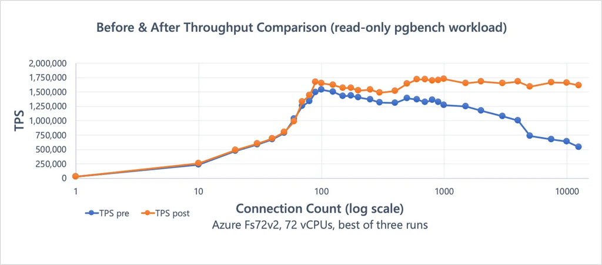

# Ateliers

- Découvrir les nouveaux rôles prédéfinis
- Mise en place d’un sharding minimal
- Outil pg_rewind

## Découvrir les nouveaux rôles prédéfinis

- Utiliser le rôle `pg_database_owner` dans une base *template*
- Exporter avec le rôle `pg_read_all_data`
- Importer avec le rôle `pg_write_all_data`

## Mise en place d’un sharding minimal

- Préparer le modèle et configurer les accès distants
- Alimenter une table partitionnée répartie dans plusieurs bases de données
- Étudier les différents cas d’usage

## Outil pg_rewind

- Création d’une instance primaire ;
- Mise en place de la réplication sur deux secondaires ;
- Promotion d’un secondaire pour réaliser des tests ;
- Utilisation de `pg_rewind` pour raccrocher l’instance secondaire à la réplication.